# Climate EDA

Devin Gamble

4/22/2020

#Exploratory Data Analysis - ClimateNA Data  
### See ‘EDA1.Rmd’ for EDA on herbarium data alone (and CA Maps of some climate variables)

Import ClimateNA data:

# Climate Normals/ Long-term Averages

## Annual Variables

#### 1951 - 1980

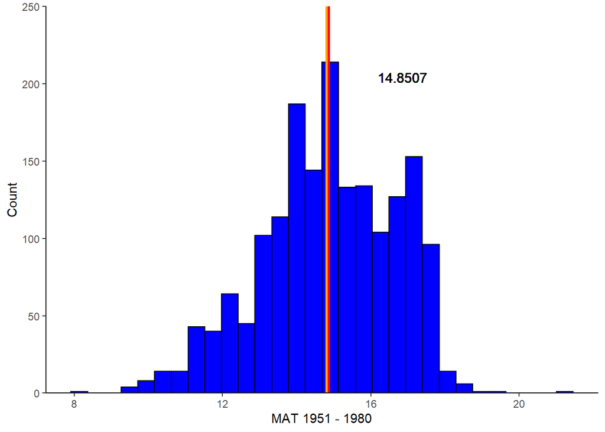

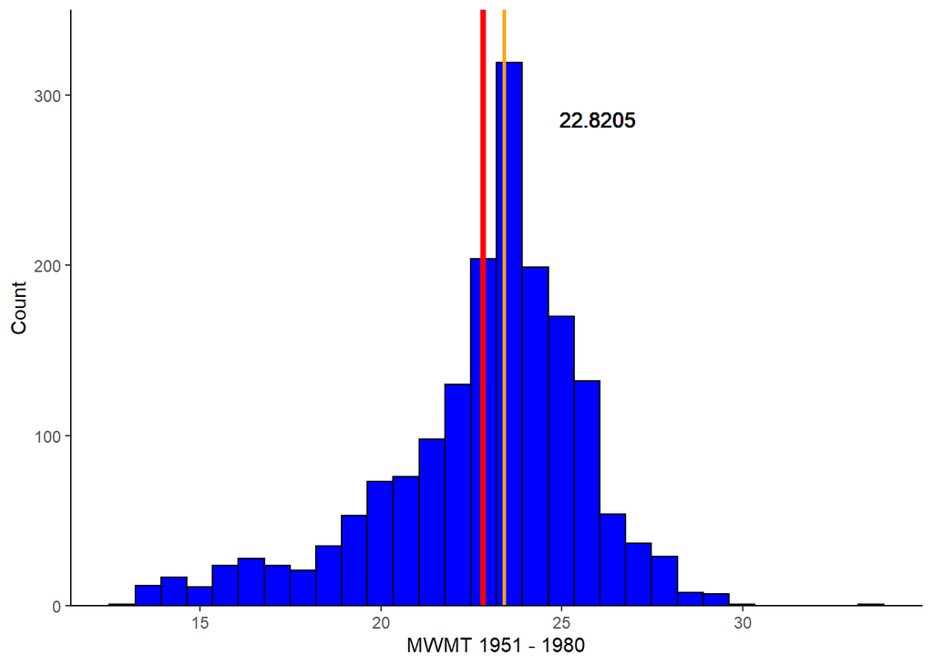

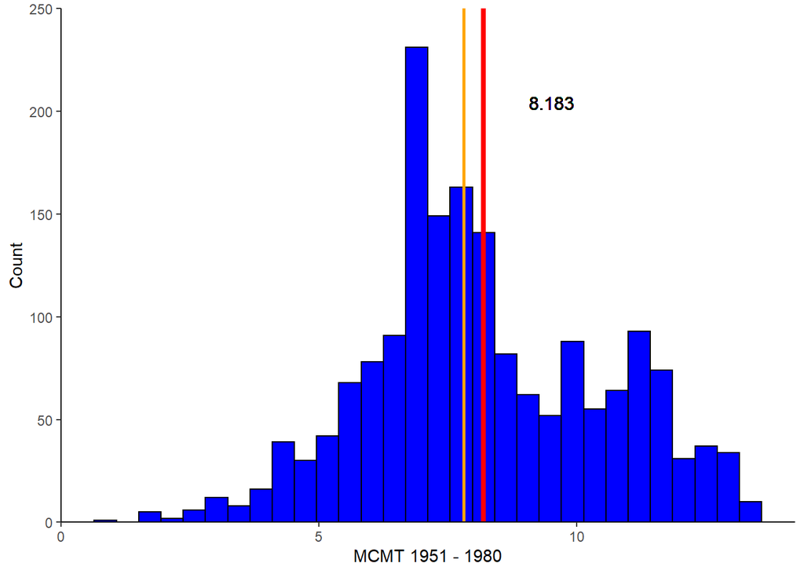

Annual Temp distributions look okay.

Precipitation

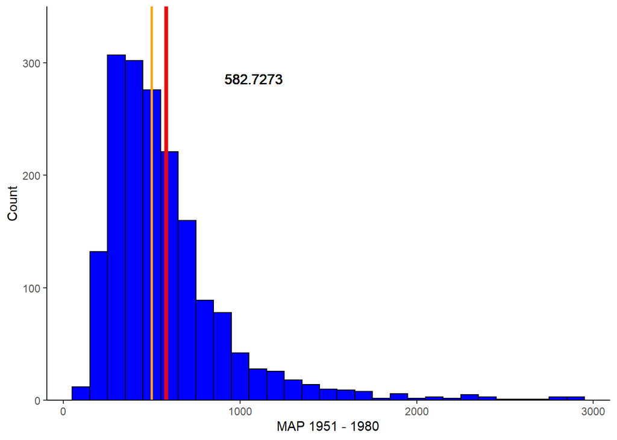

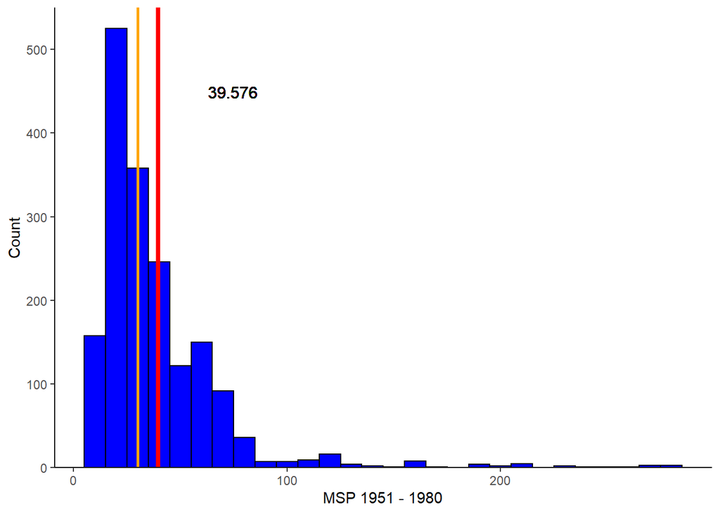

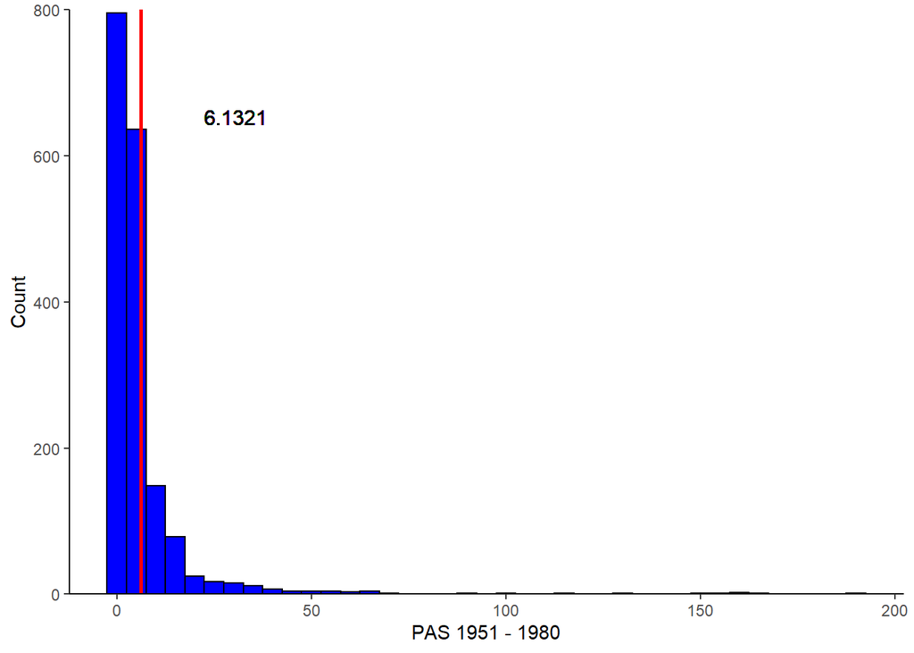

Looks like most precipitation parameters will need some kind of transformation - log. There also look to be a lot of outliers.

**Log Transformed** Precipitation:

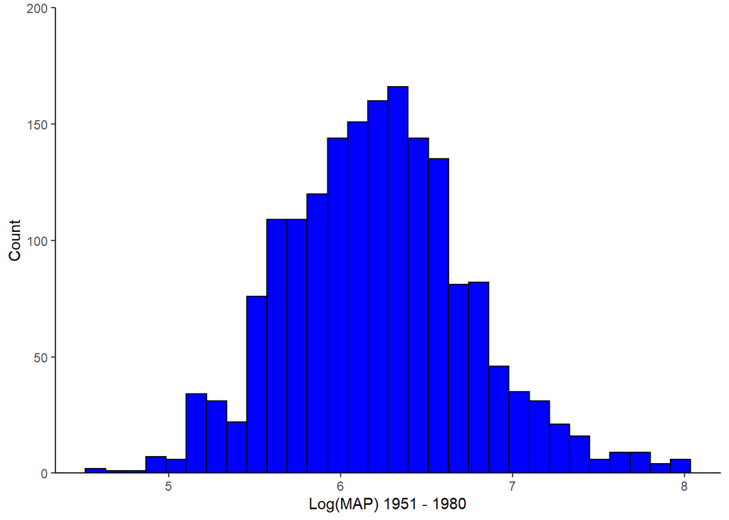

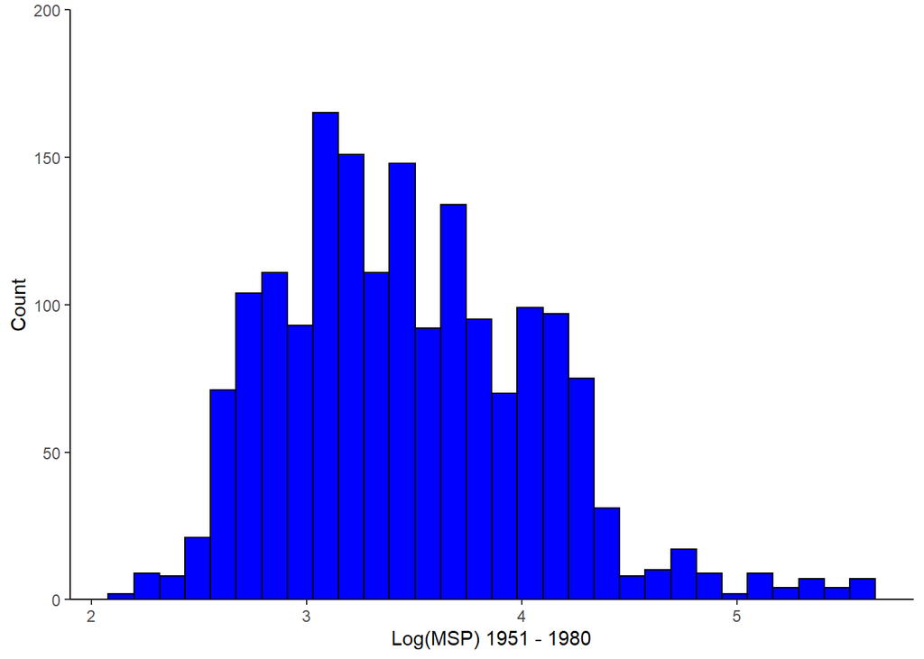

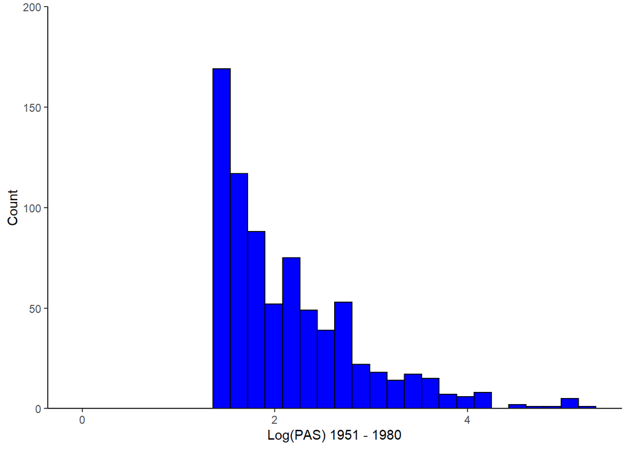

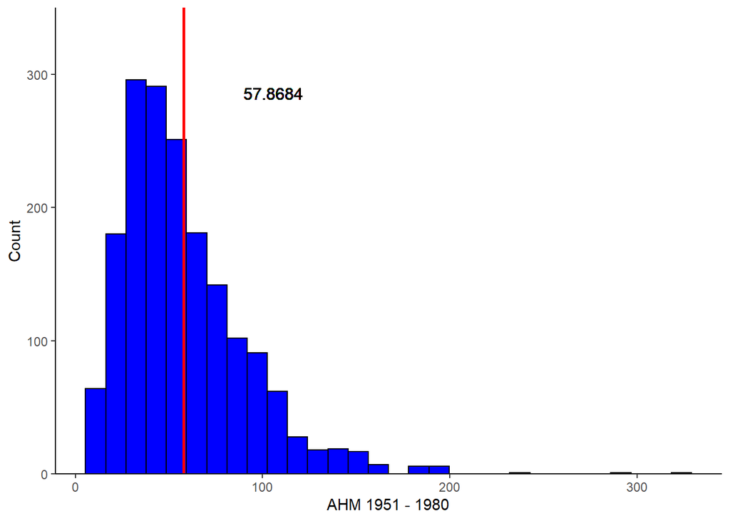

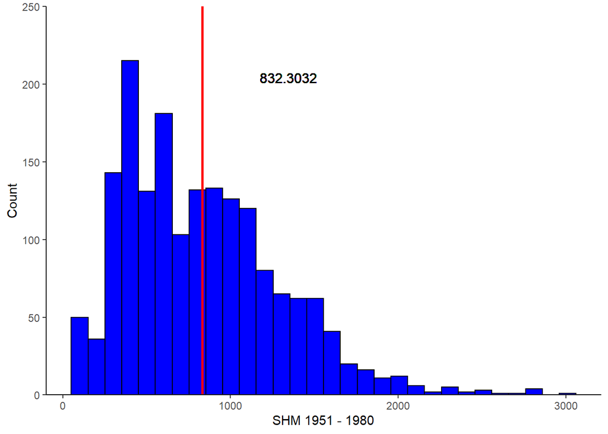

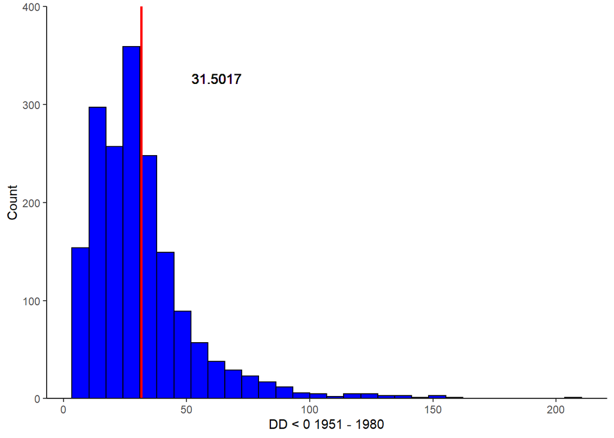

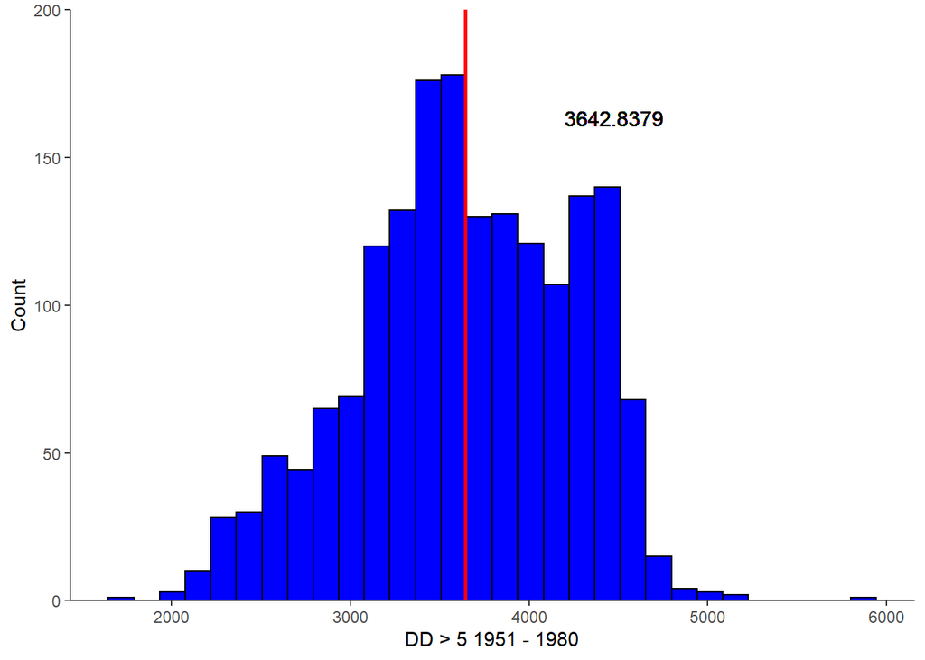

[figure not shown]

I don’t understand why DD > 5 has values over 365 days (and over 31 days for monthly variables), in all climateNA files?? They are the cumulative degrees in a period (month, season, year) for days where temps are under 0/over 5.

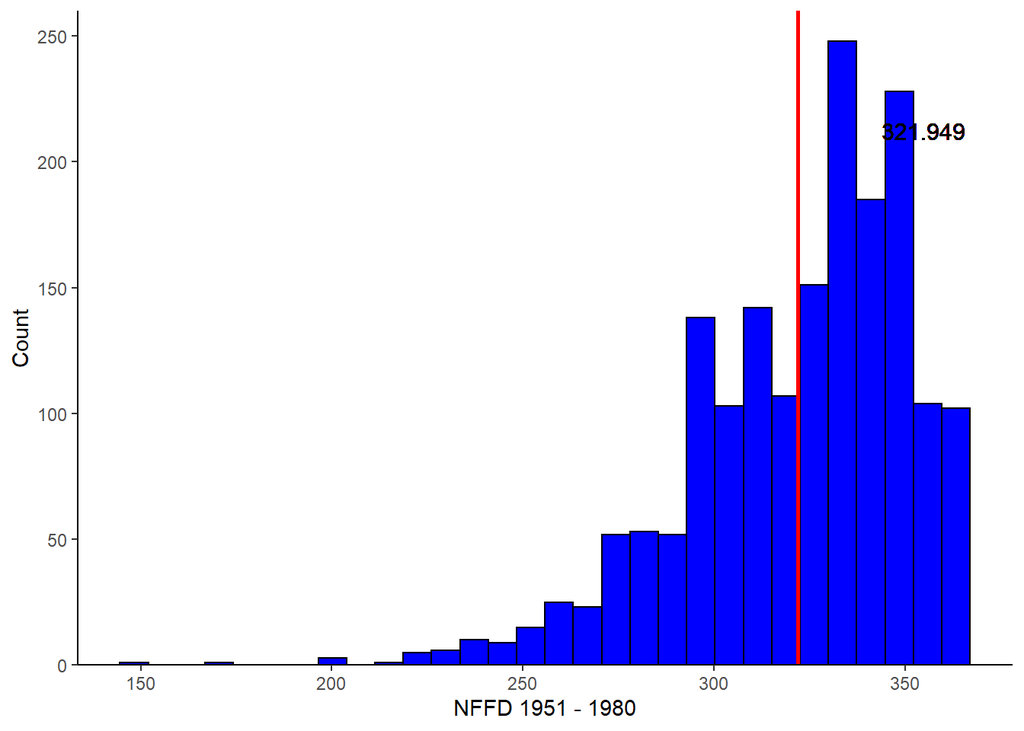

[figure not shown]

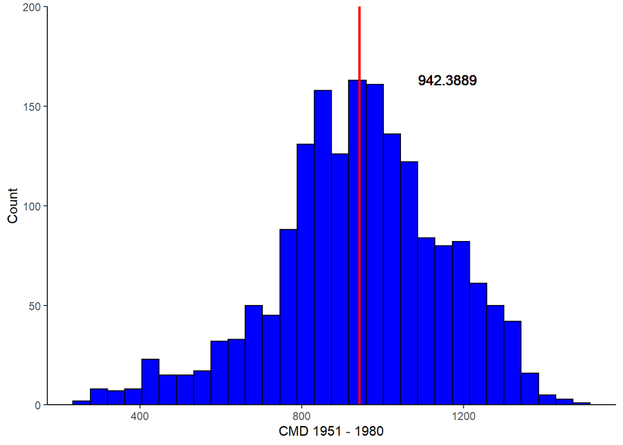

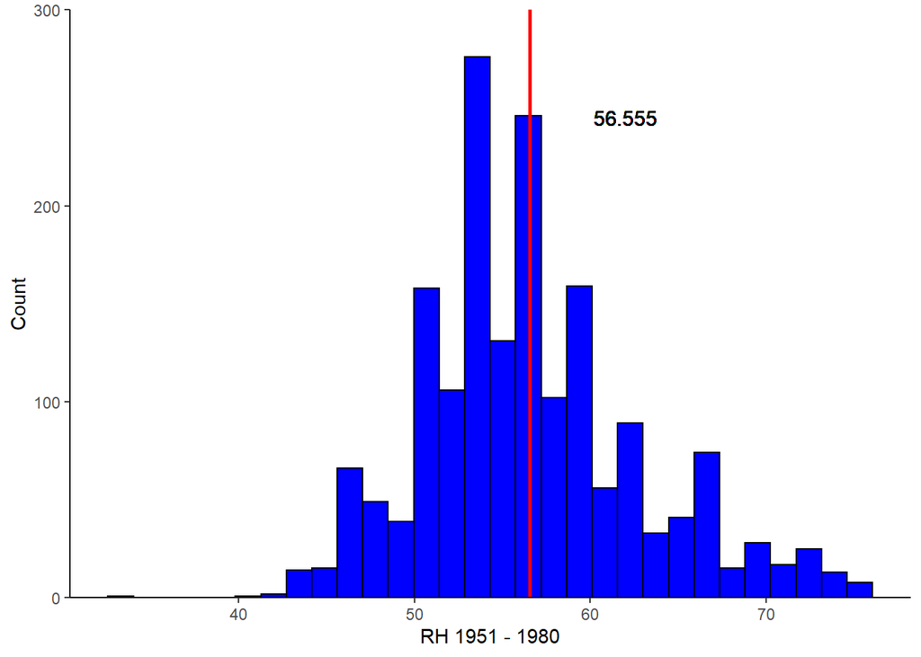

It seems likely that a lot of the skew in the above variables may be associated with the skew in elevation - fewer specimens collected at high elevations, but tail out into extremes.

##### Climate Anomalies

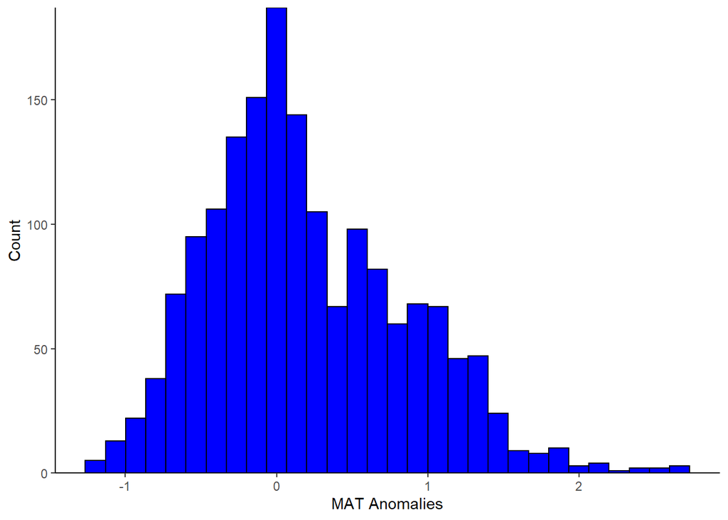

```r
ggplot(data = climNA_all, aes(x = MAT_A)) +
  geom_histogram(fill = "blue", color = "black") +
  theme_classic() +
  scale_y_continuous(expand = c(0,0)) +
  ylab("Count") +
  xlab("MAT Anomalies")
```

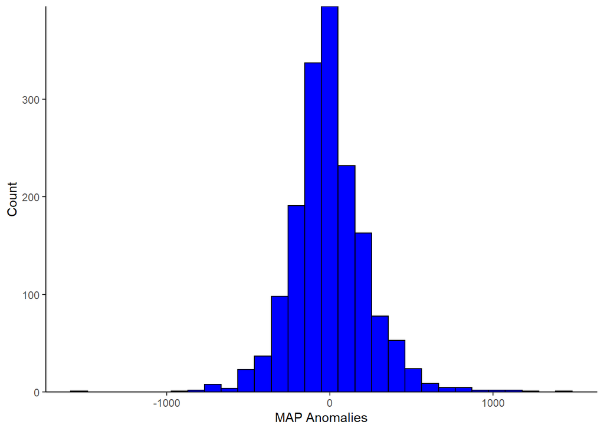

```r
#Does PPT_A need to be log transformed or scaled somehow?
ggplot(data = climNA_all, aes(x = MAP_A)) +
  geom_histogram(fill = "blue", color = "black") +
  theme_classic() +
  scale_y_continuous(expand = c(0,0)) +
  ylab("Count") +
  xlab("MAP Anomalies")
```

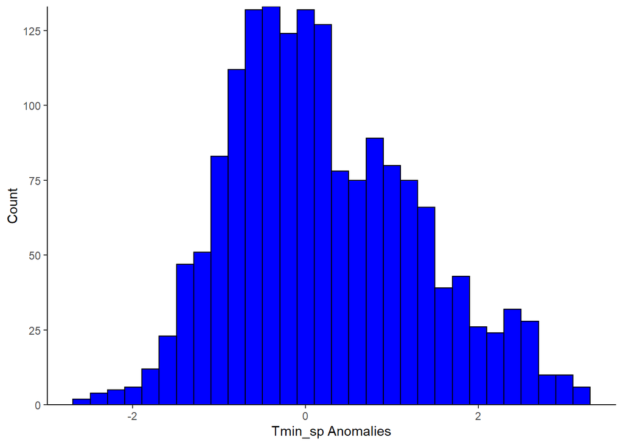

```r
ggplot(data = climNA_all, aes(x = Tmin_sp_A)) +
  geom_histogram(fill = "blue", color = "black") +
  theme_classic() +
  scale_y_continuous(expand = c(0,0)) +
  ylab("Count") +
  xlab("Tmin_sp Anomalies")
```

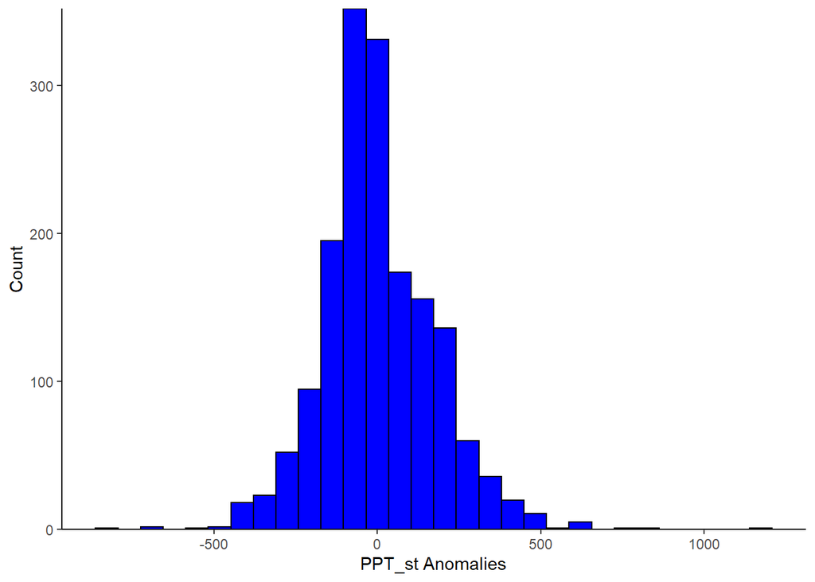

```r
ggplot(data = climNA_all, aes(x = PPT_wt_A)) +
  geom_histogram(fill = "blue", color = "black") +
  theme_classic() +
  scale_y_continuous(expand = c(0,0)) +
  ylab("Count") +
  xlab("PPT_st Anomalies")
```

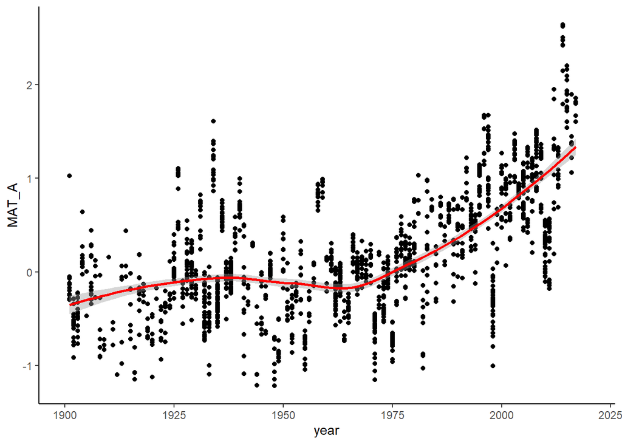

```r
#Everything is pretty normally distributed



#ANOMALIES over time
ggplot(data = climNA_all, aes(x = year, y = MAT_A)) +
  geom_point() +
  geom_smooth(method = "loess", col = "red") +
  scale_x_continuous(limits = c(1900, 2020)) +
  theme_classic()
```

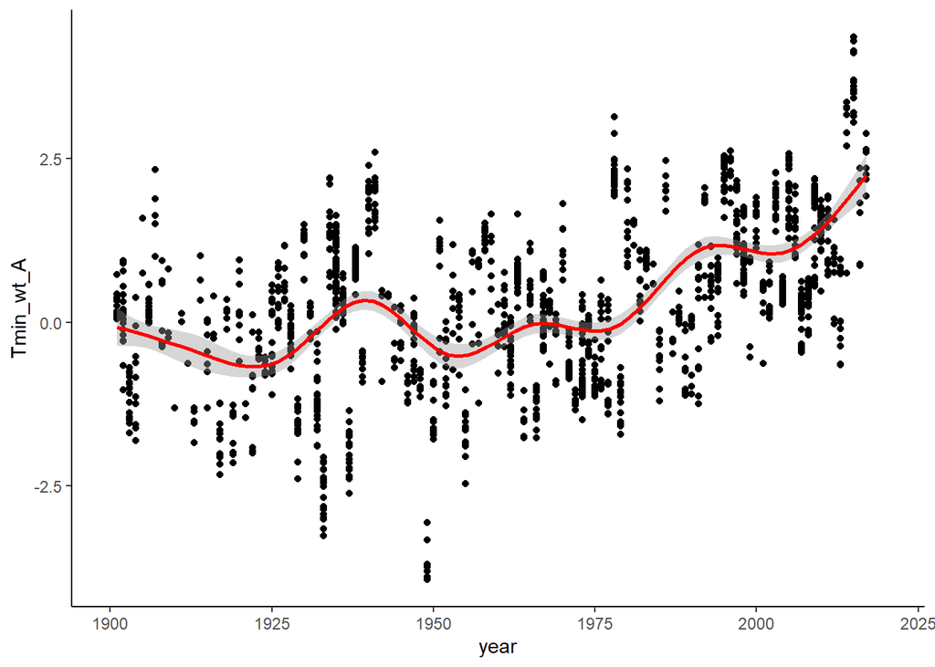

```r
#gam fit is also cool

ggplot(data = climNA_all, aes(x = year, y = Tmin_wt_A)) +
  geom_point() +
  geom_smooth(method = "gam", col = "red") +
  scale_x_continuous(limits = c(1900, 2020)) +
  theme_classic()
```

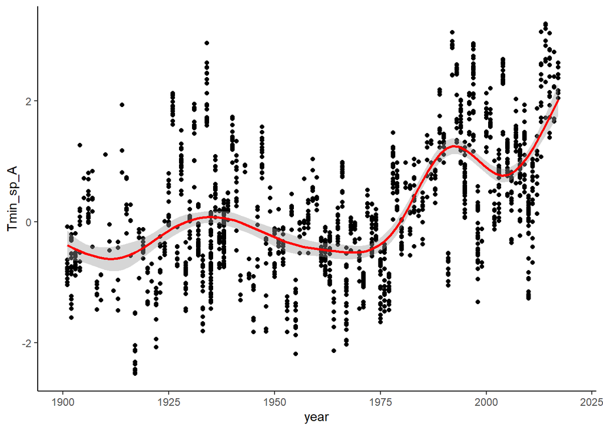

```r
ggplot(data = climNA_all, aes(x = year, y = Tmin_sp_A)) +
  geom_point() +
  geom_smooth(method = "gam", col = "red") +
  scale_x_continuous(limits = c(1900, 2020)) +
  theme_classic()
```

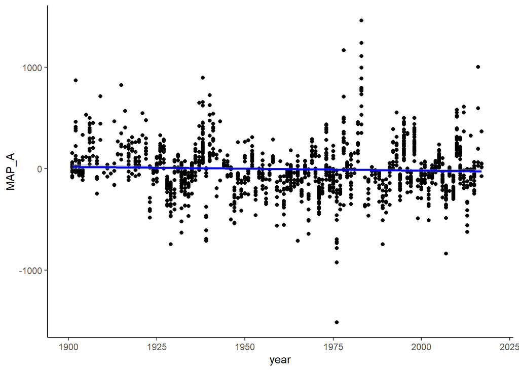

```r
#PPT
ggplot(data = climNA_all, aes(x = year, y = MAP_A)) +
  geom_point() +
  geom_smooth(method = "lm", col = "blue") +
  scale_x_continuous(limits = c(1900, 2020)) +
  theme_classic()
```

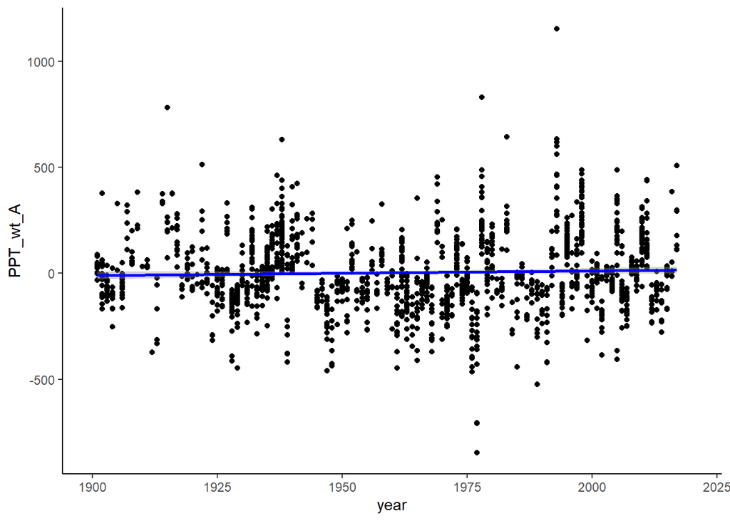

```r
#No change in PPT anomalies

ggplot(data = climNA_all, aes(x = year, y = PPT_wt_A)) +
  geom_point() +
  geom_smooth(method = "lm", col = "blue") +
  scale_x_continuous(limits = c(1900, 2020)) +
  theme_classic()
```

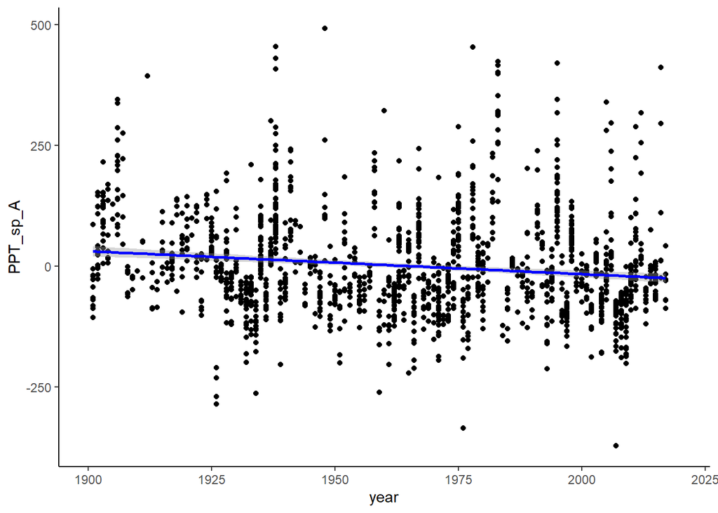

```r
ggplot(data = climNA_all, aes(x = year, y = PPT_sp_A)) +
  geom_point() +
  geom_smooth(method = "lm", col = "blue") +
  scale_x_continuous(limits = c(1900, 2020)) +
  theme_classic()
```

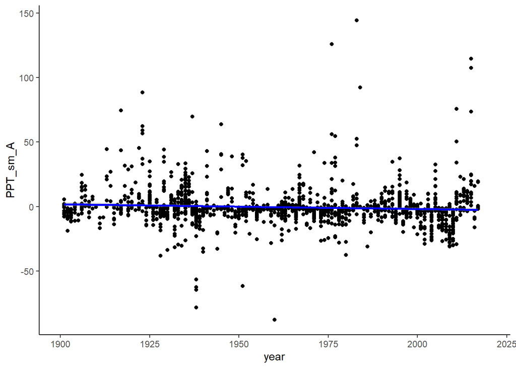

```r
#Increase in dry anomalies in the spring over time?

ggplot(data = climNA_all, aes(x = year, y = PPT_sm_A)) +
  geom_point() +
  geom_smooth(method = "lm", col = "blue") +
  scale_x_continuous(limits = c(1900, 2020)) +
  theme_classic()
```

#### All Normals/Long-term climate

Here I compare between different normal periods, since the underlying distributions are unlikely to change much in shape, but may shift over time.

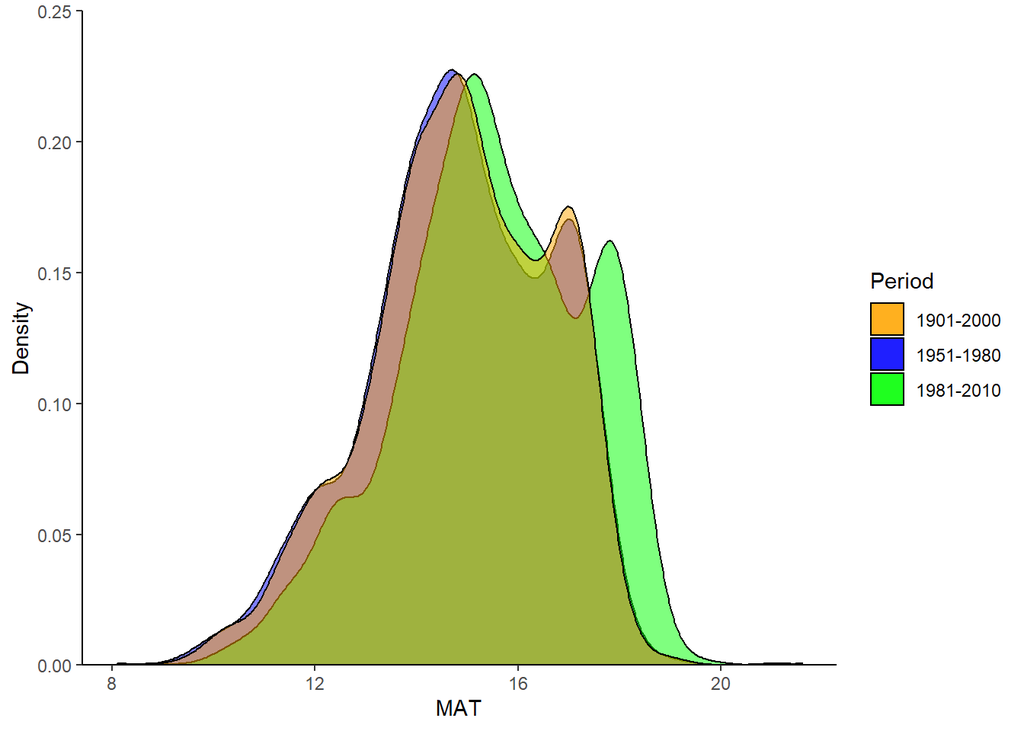

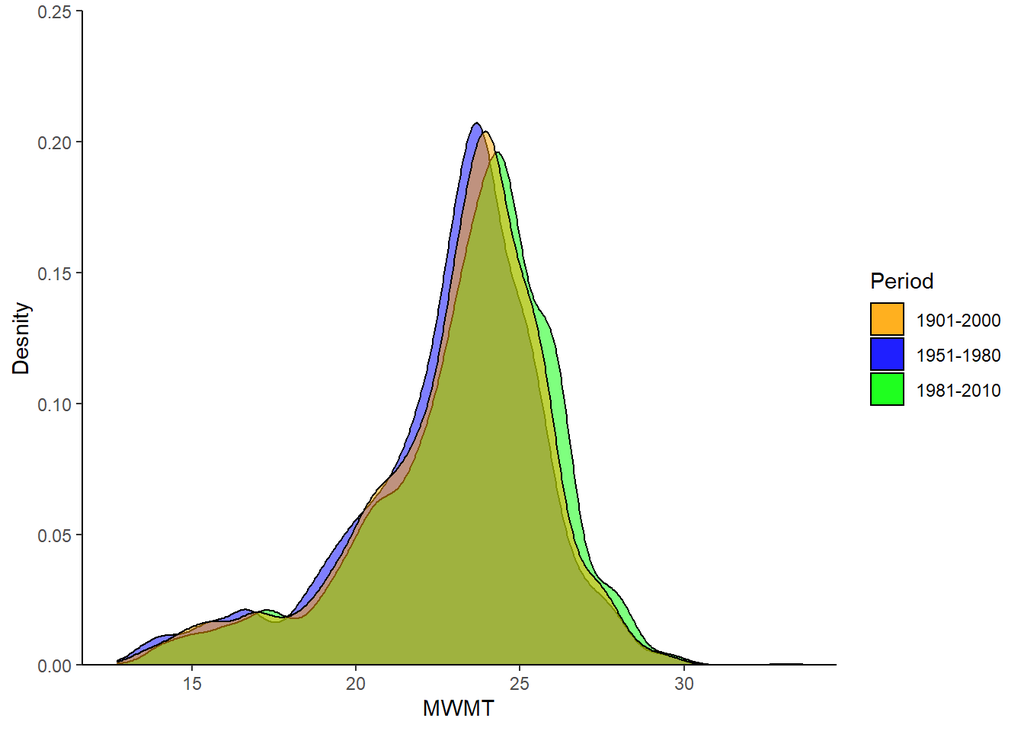

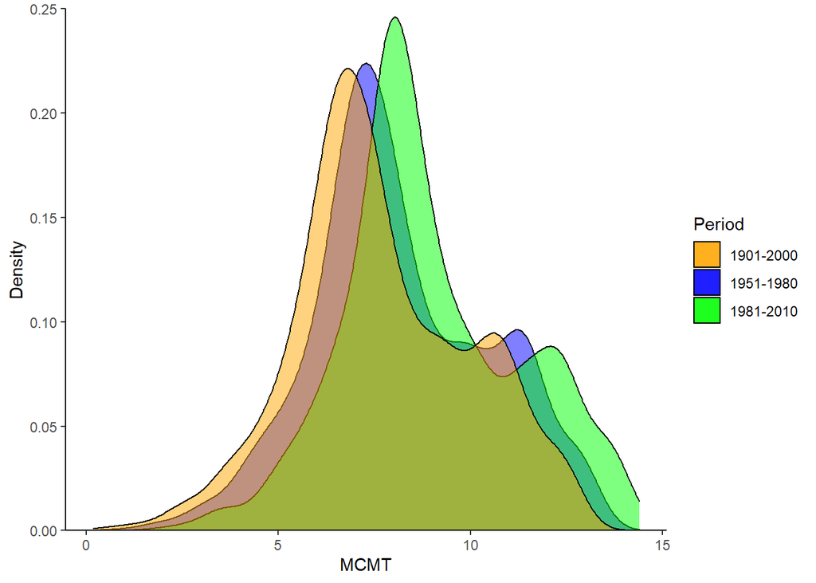

Looks like MCMT and MAT have changed more than MWMT wrt time - positive shifts from 100Y avg to ’51 Norms to `81 Norms.

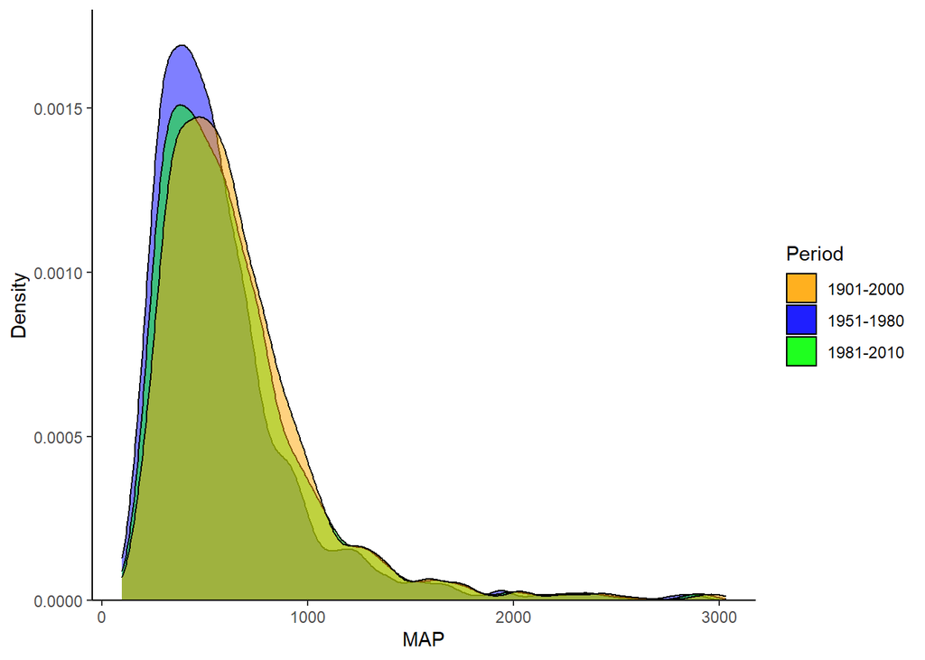

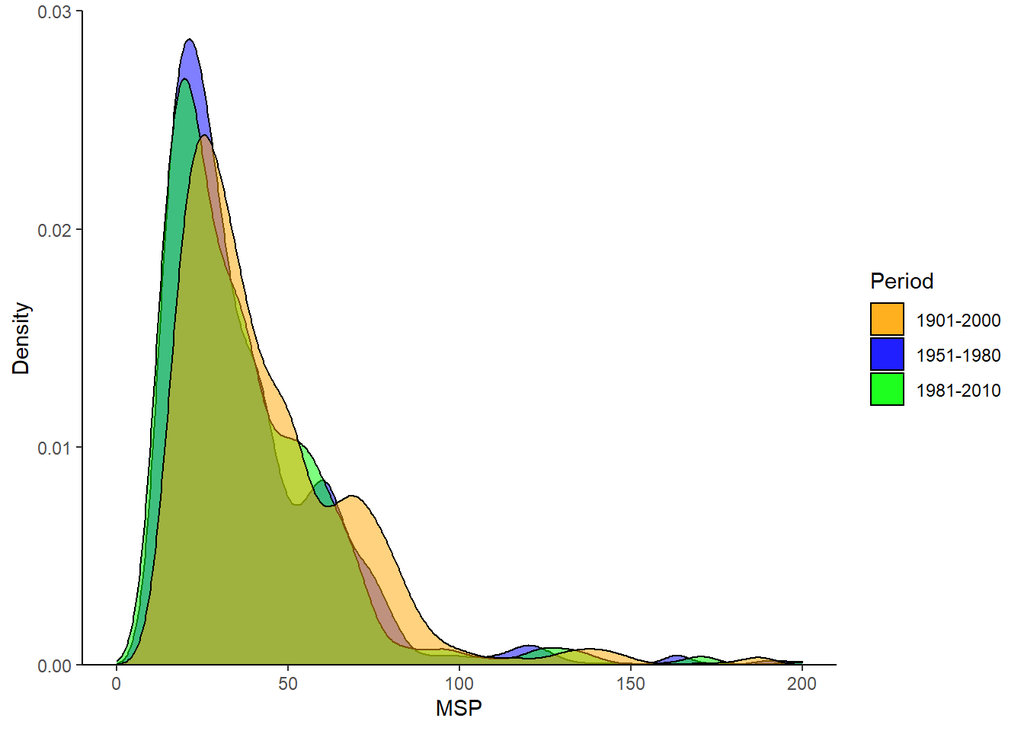

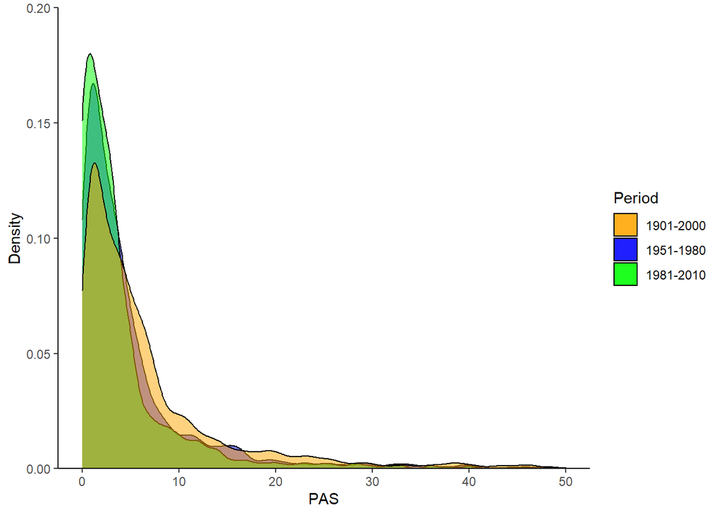

There doesn’t appear to be much difference in Precipitation among climate normals.

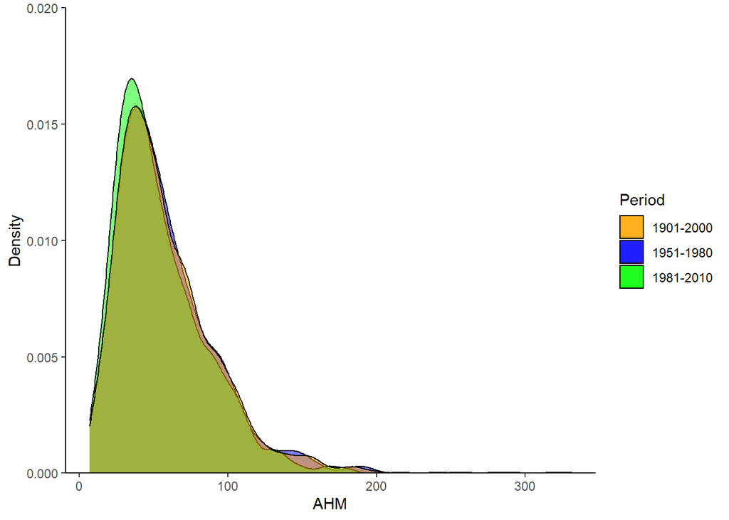

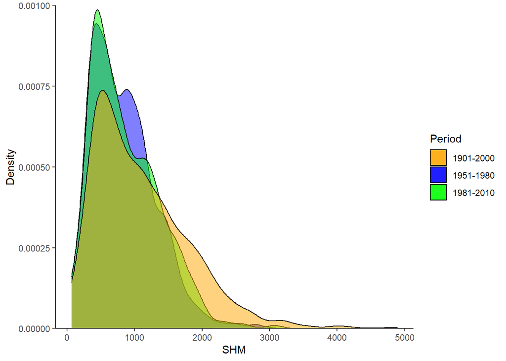

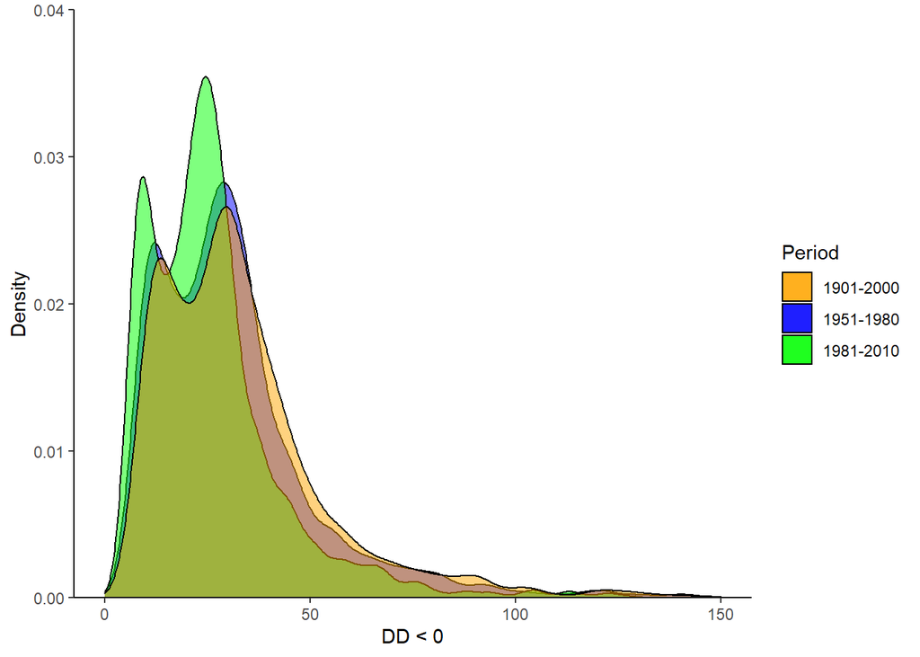

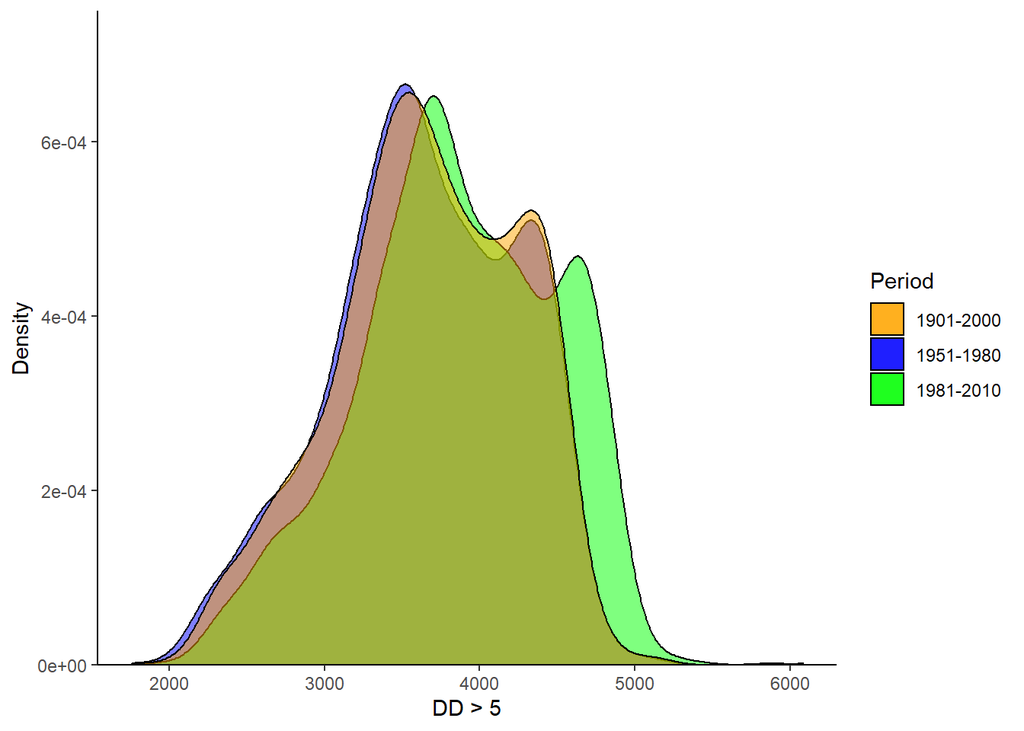

Looks like GDD (Days > 5) are becoming greater and days < 0 fewer over time (though still unsure about values).

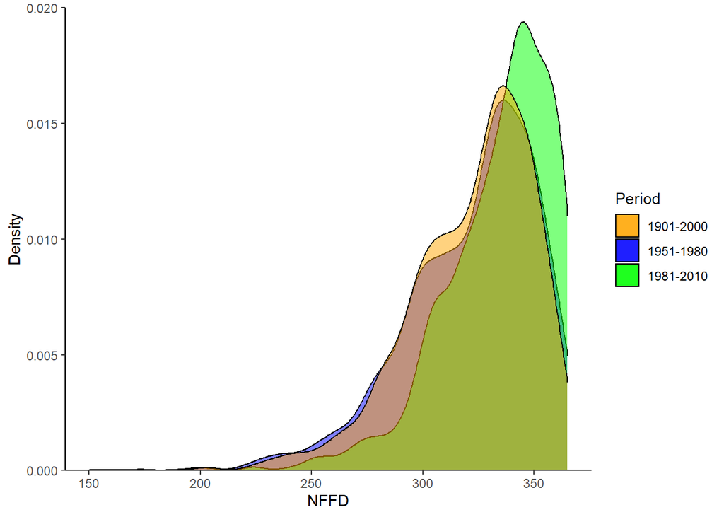

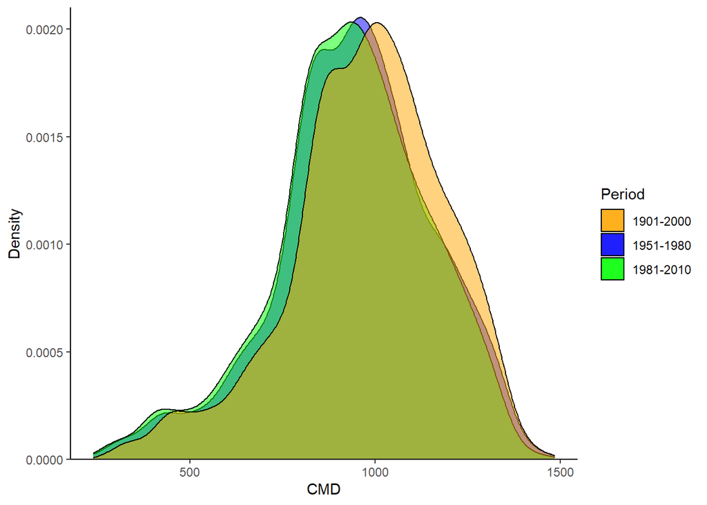

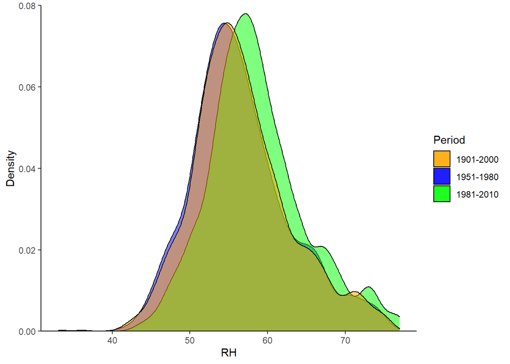

Increase in RH probably tied to temperature.

## Seasonal & Monthly Variables

### Exploring Seasonal/Monthly Temperature

#### Tmin

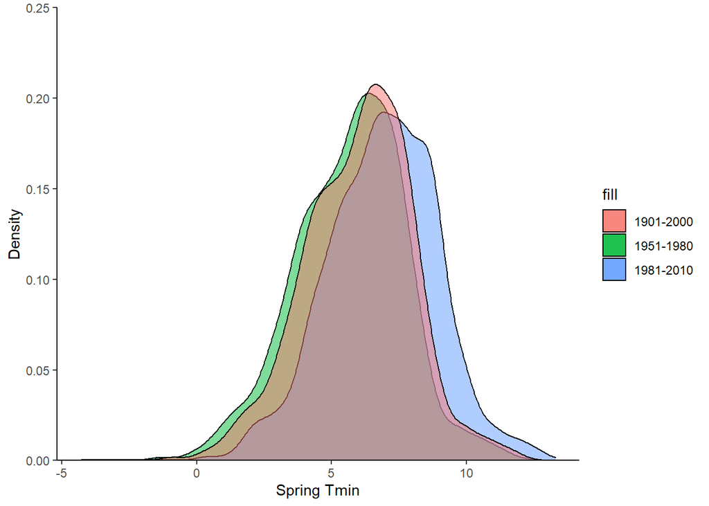

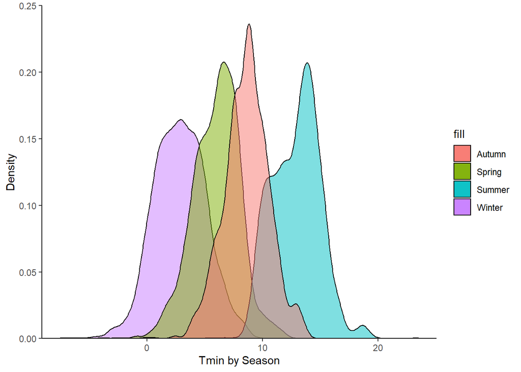

# YoC Annual Climate and Anomalies

## Looking at climates of collection across California

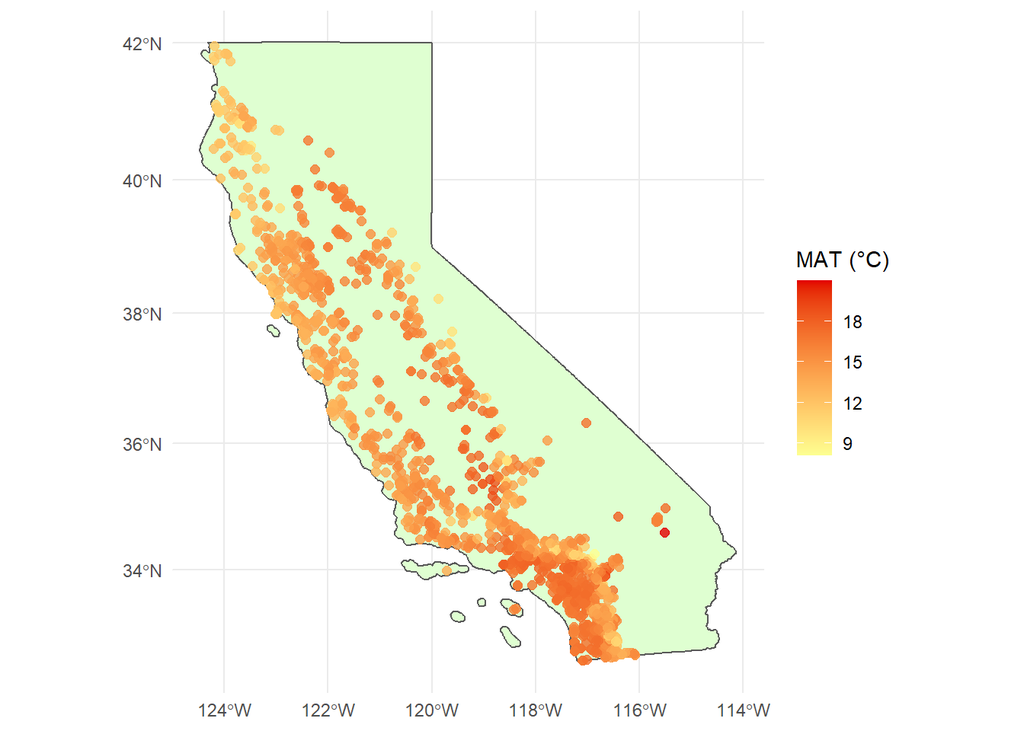

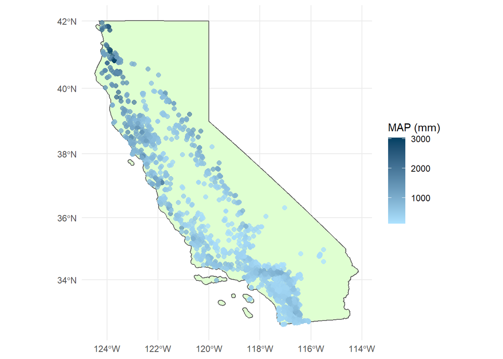

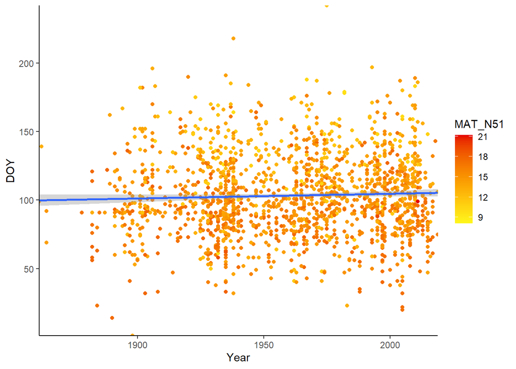

```r
#MOVE TO ANALYSES 1


newdf <- merge(nemo_all1, climNA_all)




ggplot(data = newdf, aes(x = year, y = DOY)) +
  geom_point(aes(color = MAT_N51)) +
  geom_smooth(method = "lm") +
  scale_color_gradientn(colors = c("#fff71c", "#e60000"), values = c(0, 1)) +
  theme_classic() +
  scale_y_continuous(expand = c(0,0)) +
  scale_x_continuous(expand = c(0,0)) +
  ylab("DOY") +
  xlab("Year")
```

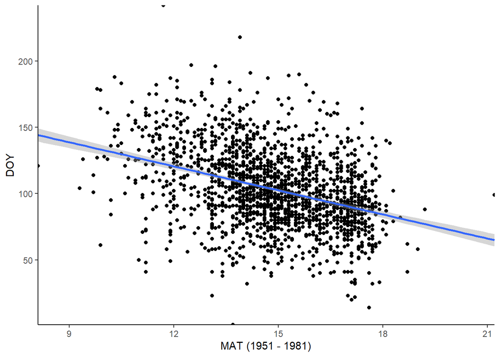

```r
ggplot(data = newdf, aes(x = MAT_N51, y = DOY)) +
  geom_point()+
  geom_smooth(method = "lm") +
  theme_classic() +
  scale_y_continuous(expand = c(0,0)) +
  scale_x_continuous(expand = c(0,0)) +
  ylab("DOY") +
  xlab("MAT (1951 - 1981)")
```

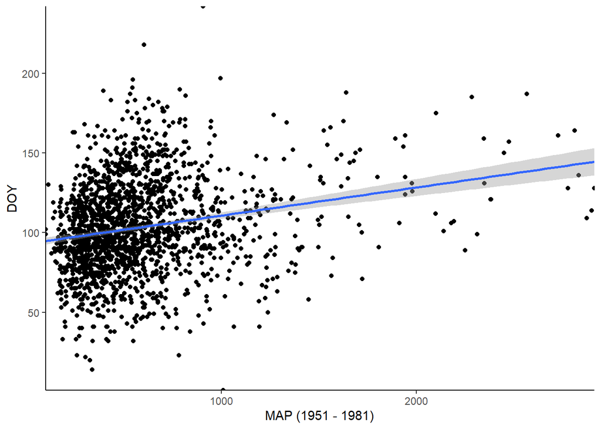

```r
ggplot(data = newdf, aes(x = MAP_N51, y = DOY)) +
  geom_point()+
  geom_smooth(method = "lm") +
  theme_classic() +
  scale_y_continuous(expand = c(0,0)) +
  scale_x_continuous(expand = c(0,0)) +
  ylab("DOY") +
  xlab("MAP (1951 - 1981)")
```